# Impact of the us of synthetic data in IPD Meta-Analysis: A simulation study

metaConvert team

2025-06-06

# 1. Methods

## 1.1 Synthetic data generation

A predetermined proportion of studies (0%, 33%, 66%, 100%) had their original (“true”) IPD replaced with synthetic versions. This was performed by the synthpop R package.

Synthesis method: A parametric approach (synthesis_method = “parametric”) was employed. synthpop dynamically selected synthesis routines based on variable type (e.g., norm for numeric, logreg for binary, polyreg for categorical factors, sample as a fallback).

## 1.2 Meta-analysis model

A one-stage IPD meta-analysis using a linear mixed-effects model was used to estimate the treatment effect. The model specification was: outcome ~ treatment01 + cont_cov + num2_cont_cov + bin_cov01 + multi_cov + (1 + treatment01 | study_id)

This model estimates the overall treatment effect while accounting for covariates and allowing for study-specific random intercepts and random slopes for the treatment effect. If this complex model failed to converge (I provide below the rate of convergence/warnings), a simpler model with only random intercepts was attempted: outcome ~ treatment01 + cont_cov + num2_cont_cov + bin_cov01 + multi_cov + (1 | study_id)

## 1.5 Performance Metrics

**Effect**

- bias_mean: Average difference between the synthetic estimate and the true treatment effect.
- bias_median: Median difference.
- rel_bias_mean_perc: Mean bias as a percentage of the true effect.

**Overall**

- RMSE: Root Mean Squared Error, combining bias and variability.

**Variance**

- avg_variance_ratio: Average ratio of synthetic analysis variance to “all-real” data analysis variance.

**95% CI**

- avg_ci_width_ratio: Average ratio of synthetic CI width to “all-real” data CI width.
- coverage_synth: Proportion of 95% CIs from synthetic analysis containing the true treatment effect.

**Heterogeneity Estimation**

- bias_tau2_mean: Mean bias in the estimation of tau_squared (treatment effect heterogeneity).

# 2. Results

This section presents the findings from the simulation study. Results are typically grouped by the performance metric under investigation and faceted by key simulation parameters to illustrate trends. Note: If all_simulation_results.rds was not found or was empty, the following sections will show placeholder messages.

## 2.1 Convergence rates

```r
summary_stats %>%
  group_by(n_studies, n_per_study_mean, prop_synthetic) %>%
  summarise(
    Scenarios = n_distinct(interaction(treatment_effect, tau_squared)),
    Mean_Converged_Prop = mean(avg_prop_converged_synth, na.rm=TRUE),
    Mean_Singular_Prop = mean(avg_prop_singular_synth, na.rm=TRUE),
    .groups="drop"
  ) %>%
  filter(prop_synthetic > 0) %>%
  kable(caption = "Average Proportion of Converged and Singular Fits in Synthetic Analyses (Aggregated).", digits = 3, format = "pipe")
```

Average Proportion of Converged and Singular Fits in Synthetic Analyses (Aggregated).

| n_studies | n_per_study_mean | prop_synthetic | Scenarios | Mean_Converged_Prop | Mean_Singular_Prop |
| --- | --- | --- | --- | --- | --- |
| 10 | 30 | 0.33 | 6 | 1 | 0.177 |
| 10 | 30 | 0.66 | 6 | 1 | 0.150 |
| 10 | 30 | 1.00 | 6 | 1 | 0.093 |
| 10 | 60 | 0.33 | 6 | 1 | 0.073 |
| 10 | 60 | 0.66 | 6 | 1 | 0.083 |
| 10 | 60 | 1.00 | 6 | 1 | 0.033 |
| 10 | 200 | 0.33 | 6 | 1 | 0.000 |
| 10 | 200 | 0.66 | 6 | 1 | 0.000 |
| 10 | 200 | 1.00 | 6 | 1 | 0.010 |
| 20 | 30 | 0.33 | 6 | 1 | 0.070 |
| 20 | 30 | 0.66 | 6 | 1 | 0.040 |
| 20 | 30 | 1.00 | 6 | 1 | 0.020 |
| 20 | 60 | 0.33 | 6 | 1 | 0.000 |
| 20 | 60 | 0.66 | 6 | 1 | 0.003 |
| 20 | 60 | 1.00 | 6 | 1 | 0.000 |
| 20 | 200 | 0.33 | 6 | 1 | 0.003 |
| 20 | 200 | 0.66 | 6 | 1 | 0.000 |
| 20 | 200 | 1.00 | 6 | 1 | 0.000 |
| 50 | 30 | 0.33 | 6 | 1 | 0.000 |
| 50 | 30 | 0.66 | 6 | 1 | 0.000 |
| 50 | 30 | 1.00 | 6 | 1 | 0.000 |
| 50 | 60 | 0.33 | 6 | 1 | 0.000 |
| 50 | 60 | 0.66 | 6 | 1 | 0.000 |
| 50 | 60 | 1.00 | 6 | 1 | 0.000 |
| 50 | 200 | 0.33 | 6 | 1 | 0.000 |
| 50 | 200 | 0.66 | 6 | 1 | 0.000 |
| 50 | 200 | 1.00 | 6 | 1 | 0.000 |

## 2.2 Overall Accuracy (RMSE)

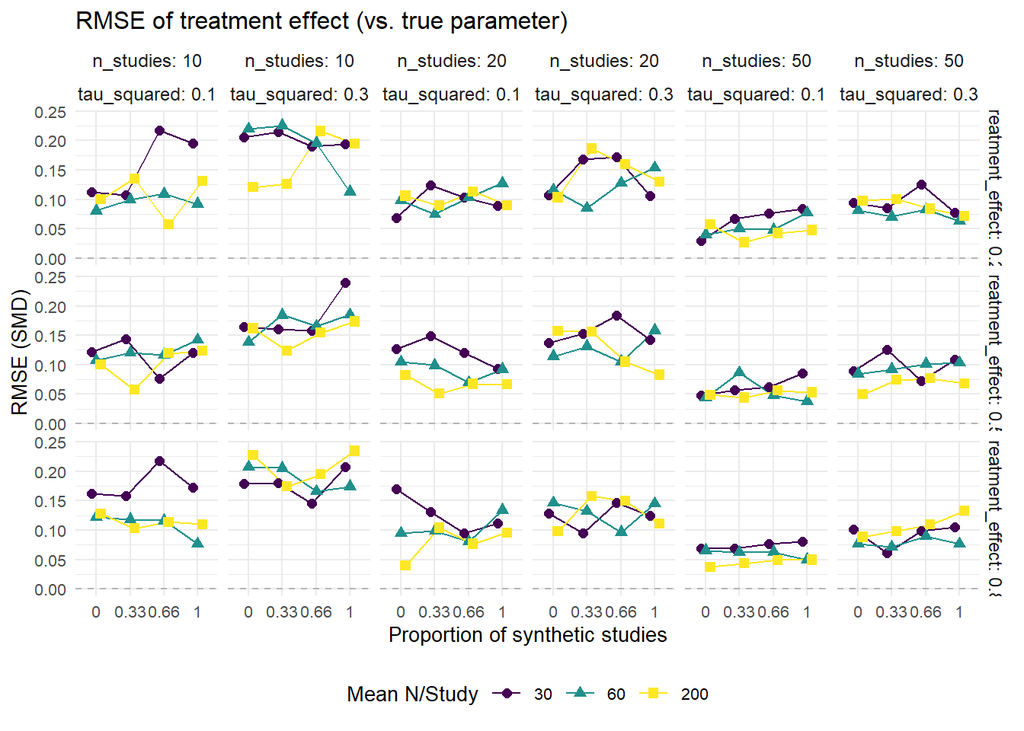

```r
generated_plots_list$p_rmse_vs_param
```

## 2.3 Treatment effect

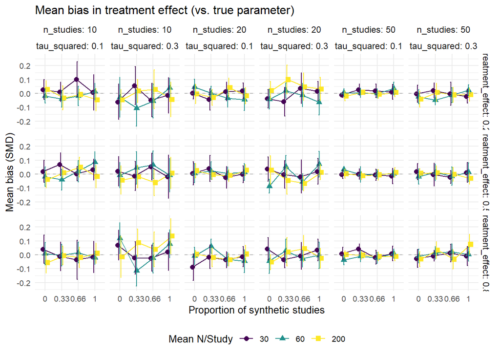

```r
generated_plots_list$p_bias_mean_vs_param
```

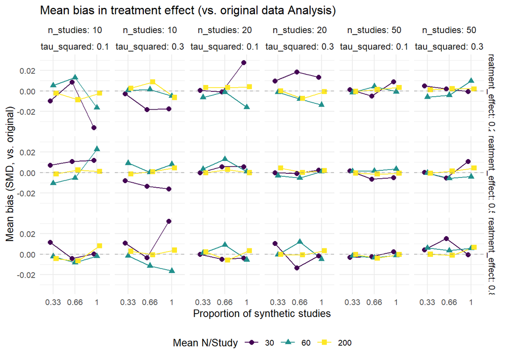

```r
generated_plots_list$p_bias_mean_vs_original
```

## 2.4 Variance

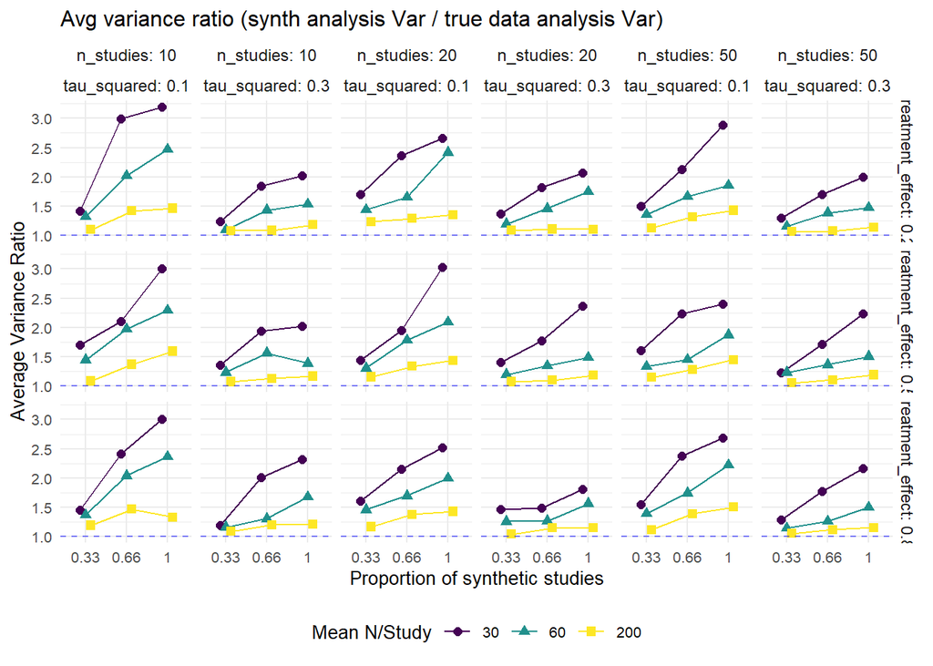

```r
generated_plots_list$p_variance_ratio
```

## 2.5 Confidence interval

Coverage probability

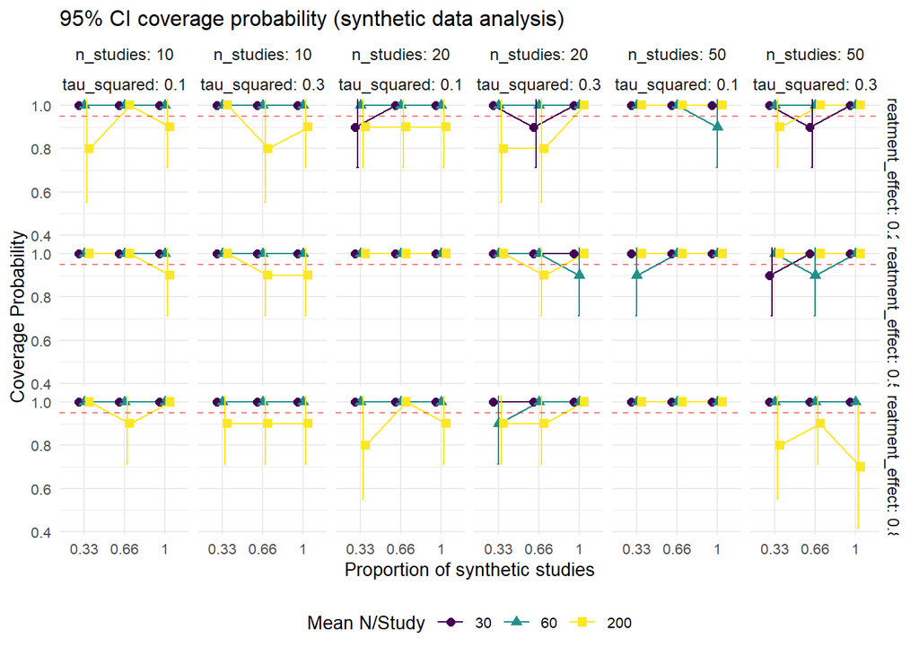

```r
generated_plots_list$p_coverage_synth
```

95% width ratio

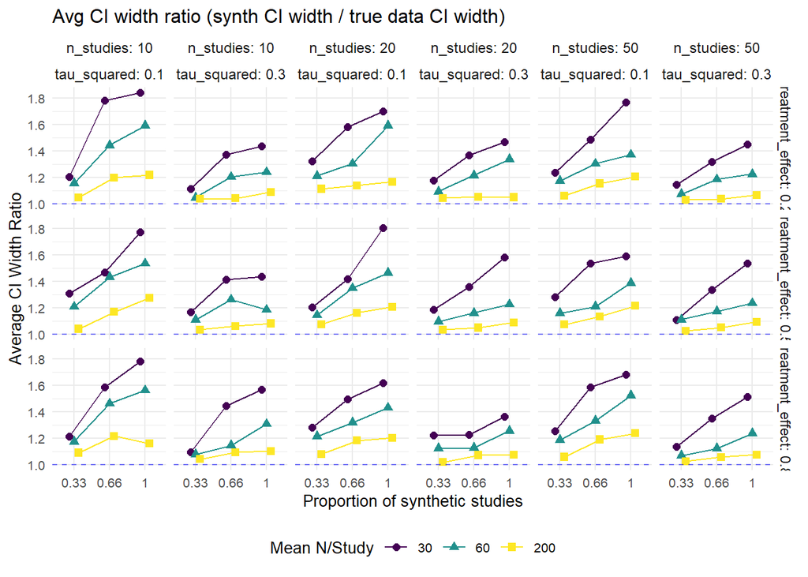

```r
generated_plots_list$p_ci_width_ratio
```

## 2.6 Between-study heterogeneity

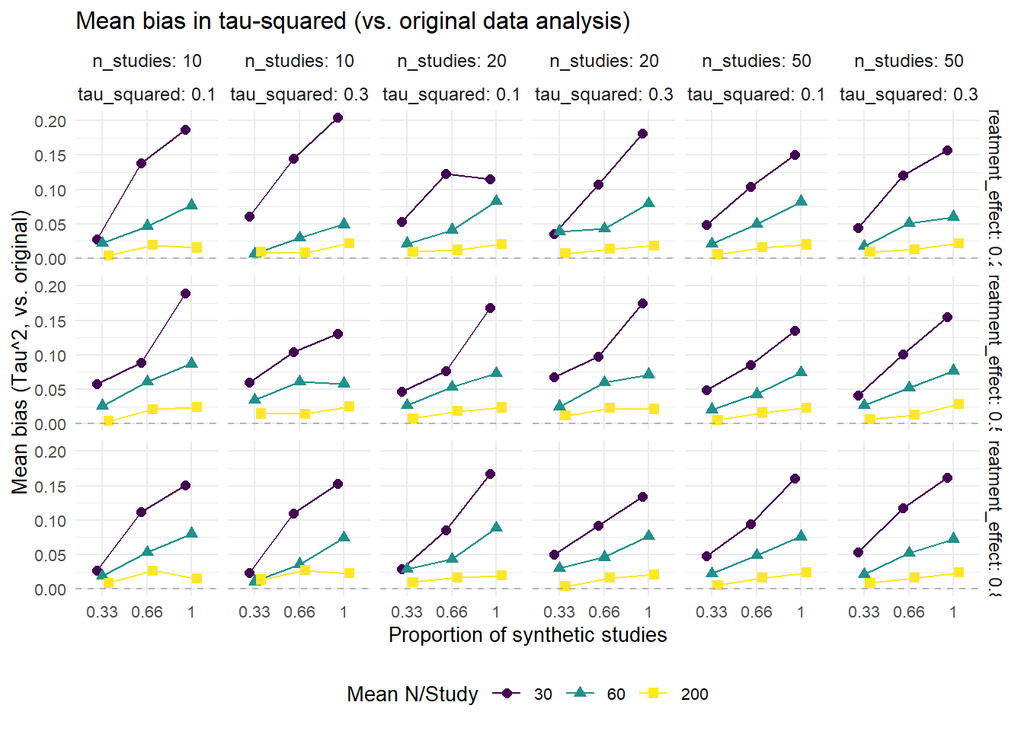

```r
generated_plots_list$p_bias_tau2_vs_original
```

## 2.7 Summary tables

```r
generated_tables_list$main_performance_summary
```

| n_studies | n_per_study_mean | treatment_effect | tau_squared | prop_synthetic | m_value | synthesis_method | n_per_study_cv | bias_mean | bias_mcse | rmse | rel_bias_mean_perc | mean_bias_effect_vs_original | mean_relative_bias_vs_original_perc | mean_bias_tau_squared_vs_original | emp_se_synth | avg_model_se_synth | se_ratio_model_emp | avg_variance_ratio | avg_ci_width_synth | avg_ci_width_ratio | coverage_synth | coverage_synth_mcse | type_i_error | power | mean_synth_tau_squared | bias_tau2_mean | n_sims_successful_analysis |
| --- | --- | --- | --- | --- | --- | --- | --- | --- | --- | --- | --- | --- | --- | --- | --- | --- | --- | --- | --- | --- | --- | --- | --- | --- | --- | --- | --- |
| 10 | 30 | 0.2 | 0.1 | 0.00 | 1 | parametric | 0.25 | 0.027 | 0.036 | 0.112 | 13.744 | 0.000 | 0.000 | 0.000 | 0.115 | 0.166 | 1.447 | 1.000 | 0.652 | 1.000 | 1.0 | 0.000 | NA | 0.3 | 0.144 | 0.044 | 10 |
| 10 | 30 | 0.2 | 0.1 | 0.33 | 5 | parametric | 0.25 | 0.011 | 0.036 | 0.108 | 5.481 | -0.010 | -7.171 | 0.028 | 0.113 | 0.193 | 1.714 | 1.416 | 0.768 | 1.204 | 1.0 | 0.000 | NA | 0.1 | 0.160 | 0.060 | 10 |
| 10 | 30 | 0.2 | 0.1 | 0.66 | 5 | parametric | 0.25 | 0.100 | 0.064 | 0.217 | 50.202 | 0.009 | -3.499 | 0.139 | 0.203 | 0.268 | 1.321 | 2.990 | 1.109 | 1.783 | 1.0 | 0.000 | NA | 0.2 | 0.267 | 0.167 | 10 |
| 10 | 30 | 0.2 | 0.1 | 1.00 | 5 | parametric | 0.25 | 0.007 | 0.065 | 0.195 | 3.658 | -0.036 | 16.403 | 0.188 | 0.206 | 0.255 | 1.241 | 3.197 | 1.042 | 1.843 | 1.0 | 0.000 | NA | 0.2 | 0.280 | 0.180 | 10 |
| 10 | 30 | 0.2 | 0.3 | 0.00 | 1 | parametric | 0.25 | -0.061 | 0.065 | 0.206 | -30.284 | 0.000 | 0.000 | 0.000 | 0.207 | 0.208 | 1.005 | 1.000 | 0.816 | 1.000 | 0.9 | 0.095 | NA | 0.0 | 0.286 | -0.014 | 10 |
| 10 | 30 | 0.2 | 0.3 | 0.33 | 5 | parametric | 0.25 | 0.056 | 0.069 | 0.215 | 27.763 | -0.003 | -4.746 | 0.061 | 0.219 | 0.236 | 1.077 | 1.239 | 0.926 | 1.113 | 1.0 | 0.000 | NA | 0.2 | 0.372 | 0.072 | 10 |
| 10 | 30 | 0.2 | 0.3 | 0.66 | 5 | parametric | 0.25 | -0.047 | 0.061 | 0.190 | -23.560 | -0.018 | -5.554 | 0.145 | 0.194 | 0.279 | 1.436 | 1.837 | 1.115 | 1.374 | 1.0 | 0.000 | NA | 0.1 | 0.477 | 0.177 | 10 |
| 10 | 30 | 0.2 | 0.3 | 1.00 | 5 | parametric | 0.25 | -0.015 | 0.064 | 0.194 | -7.414 | -0.018 | -37.171 | 0.205 | 0.203 | 0.303 | 1.488 | 2.025 | 1.208 | 1.437 | 1.0 | 0.000 | NA | 0.0 | 0.559 | 0.259 | 10 |
| 10 | 30 | 0.5 | 0.1 | 0.00 | 1 | parametric | 0.25 | 0.019 | 0.040 | 0.121 | 3.888 | 0.000 | 0.000 | 0.000 | 0.126 | 0.150 | 1.189 | 1.000 | 0.588 | 1.000 | 1.0 | 0.000 | NA | 0.9 | 0.082 | -0.018 | 10 |
| 10 | 30 | 0.5 | 0.1 | 0.33 | 5 | parametric | 0.25 | 0.070 | 0.042 | 0.144 | 13.935 | 0.007 | 0.905 | 0.057 | 0.132 | 0.224 | 1.692 | 1.697 | 0.894 | 1.311 | 1.0 | 0.000 | NA | 0.8 | 0.251 | 0.151 | 10 |
| 10 | 30 | 0.5 | 0.1 | 0.66 | 5 | parametric | 0.25 | 0.002 | 0.026 | 0.077 | 0.427 | 0.011 | 3.881 | 0.088 | 0.081 | 0.207 | 2.559 | 2.102 | 0.832 | 1.470 | 1.0 | 0.000 | NA | 0.8 | 0.168 | 0.068 | 10 |
| 10 | 30 | 0.5 | 0.1 | 1.00 | 5 | parametric | 0.25 | 0.032 | 0.039 | 0.121 | 6.490 | 0.012 | 2.039 | 0.190 | 0.122 | 0.265 | 2.166 | 3.001 | 1.078 | 1.772 | 1.0 | 0.000 | NA | 0.6 | 0.311 | 0.211 | 10 |
| 10 | 30 | 0.5 | 0.3 | 0.00 | 1 | parametric | 0.25 | 0.020 | 0.054 | 0.164 | 4.099 | 0.000 | 0.000 | 0.000 | 0.172 | 0.212 | 1.233 | 1.000 | 0.830 | 1.000 | 1.0 | 0.000 | NA | 0.6 | 0.312 | 0.012 | 10 |
| 10 | 30 | 0.5 | 0.3 | 0.33 | 5 | parametric | 0.25 | -0.015 | 0.053 | 0.160 | -2.926 | -0.008 | -2.473 | 0.060 | 0.168 | 0.240 | 1.427 | 1.356 | 0.946 | 1.169 | 1.0 | 0.000 | NA | 0.4 | 0.369 | 0.069 | 10 |
| 10 | 30 | 0.5 | 0.3 | 0.66 | 5 | parametric | 0.25 | 0.053 | 0.049 | 0.158 | 10.676 | -0.013 | -1.927 | 0.104 | 0.157 | 0.254 | 1.625 | 1.943 | 1.022 | 1.414 | 1.0 | 0.000 | NA | 0.6 | 0.335 | 0.035 | 10 |
| 10 | 30 | 0.5 | 0.3 | 1.00 | 5 | parametric | 0.25 | -0.019 | 0.080 | 0.240 | -3.734 | -0.016 | -0.623 | 0.130 | 0.252 | 0.283 | 1.125 | 2.026 | 1.136 | 1.438 | 1.0 | 0.000 | NA | 0.3 | 0.435 | 0.135 | 10 |
| 10 | 30 | 0.8 | 0.1 | 0.00 | 1 | parametric | 0.25 | 0.041 | 0.052 | 0.161 | 5.161 | 0.000 | 0.000 | 0.000 | 0.164 | 0.165 | 1.002 | 1.000 | 0.646 | 1.000 | 1.0 | 0.000 | NA | 1.0 | 0.129 | 0.029 | 10 |
| 10 | 30 | 0.8 | 0.1 | 0.33 | 5 | parametric | 0.25 | -0.011 | 0.053 | 0.158 | -1.396 | 0.012 | 1.481 | 0.026 | 0.166 | 0.178 | 1.072 | 1.455 | 0.706 | 1.215 | 1.0 | 0.000 | NA | 1.0 | 0.096 | -0.004 | 10 |
| 10 | 30 | 0.8 | 0.1 | 0.66 | 5 | parametric | 0.25 | -0.036 | 0.072 | 0.218 | -4.440 | -0.004 | -1.299 | 0.112 | 0.227 | 0.229 | 1.010 | 2.412 | 0.928 | 1.587 | 1.0 | 0.000 | NA | 0.8 | 0.198 | 0.098 | 10 |
| 10 | 30 | 0.8 | 0.1 | 1.00 | 5 | parametric | 0.25 | -0.017 | 0.057 | 0.172 | -2.076 | 0.000 | 0.640 | 0.151 | 0.181 | 0.267 | 1.478 | 3.008 | 1.094 | 1.781 | 1.0 | 0.000 | NA | 0.9 | 0.272 | 0.172 | 10 |
| 10 | 30 | 0.8 | 0.3 | 0.00 | 1 | parametric | 0.25 | 0.070 | 0.055 | 0.179 | 8.714 | 0.000 | 0.000 | 0.000 | 0.173 | 0.218 | 1.257 | 1.000 | 0.855 | 1.000 | 1.0 | 0.000 | NA | 1.0 | 0.349 | 0.049 | 10 |
| 10 | 30 | 0.8 | 0.3 | 0.33 | 5 | parametric | 0.25 | -0.022 | 0.059 | 0.180 | -2.771 | 0.011 | 1.242 | 0.024 | 0.188 | 0.236 | 1.255 | 1.195 | 0.928 | 1.096 | 1.0 | 0.000 | NA | 1.0 | 0.352 | 0.052 | 10 |
| 10 | 30 | 0.8 | 0.3 | 0.66 | 5 | parametric | 0.25 | -0.023 | 0.048 | 0.146 | -2.878 | -0.004 | -0.831 | 0.110 | 0.152 | 0.256 | 1.692 | 2.014 | 1.038 | 1.445 | 1.0 | 0.000 | NA | 0.9 | 0.318 | 0.018 | 10 |
| 10 | 30 | 0.8 | 0.3 | 1.00 | 5 | parametric | 0.25 | 0.022 | 0.069 | 0.208 | 2.765 | 0.032 | 3.918 | 0.152 | 0.218 | 0.286 | 1.312 | 2.317 | 1.164 | 1.572 | 1.0 | 0.000 | NA | 0.9 | 0.394 | 0.094 | 10 |
| 10 | 60 | 0.2 | 0.1 | 0.00 | 1 | parametric | 0.25 | -0.019 | 0.026 | 0.081 | -9.347 | 0.000 | 0.000 | 0.000 | 0.083 | 0.122 | 1.472 | 1.000 | 0.480 | 1.000 | 1.0 | 0.000 | NA | 0.2 | 0.077 | -0.023 | 10 |
| 10 | 60 | 0.2 | 0.1 | 0.33 | 5 | parametric | 0.25 | -0.039 | 0.030 | 0.099 | -19.522 | 0.005 | 37.559 | 0.022 | 0.096 | 0.144 | 1.491 | 1.323 | 0.567 | 1.157 | 1.0 | 0.000 | NA | 0.1 | 0.107 | 0.007 | 10 |
| 10 | 60 | 0.2 | 0.1 | 0.66 | 5 | parametric | 0.25 | -0.019 | 0.036 | 0.109 | -9.682 | 0.013 | 11.505 | 0.047 | 0.114 | 0.152 | 1.338 | 2.017 | 0.609 | 1.444 | 1.0 | 0.000 | NA | 0.2 | 0.095 | -0.005 | 10 |
| 10 | 60 | 0.2 | 0.1 | 1.00 | 5 | parametric | 0.25 | 0.012 | 0.031 | 0.092 | 6.183 | -0.016 | -4.286 | 0.077 | 0.097 | 0.187 | 1.940 | 2.473 | 0.758 | 1.594 | 1.0 | 0.000 | NA | 0.0 | 0.179 | 0.079 | 10 |
| 10 | 60 | 0.2 | 0.3 | 0.00 | 1 | parametric | 0.25 | -0.028 | 0.073 | 0.220 | -14.026 | 0.000 | 0.000 | 0.000 | 0.230 | 0.204 | 0.887 | 1.000 | 0.799 | 1.000 | 0.9 | 0.095 | NA | 0.2 | 0.355 | 0.055 | 10 |
| 10 | 60 | 0.2 | 0.3 | 0.33 | 5 | parametric | 0.25 | -0.106 | 0.066 | 0.226 | -52.841 | 0.001 | 17.261 | 0.007 | 0.210 | 0.245 | 1.163 | 1.097 | 0.961 | 1.048 | 1.0 | 0.000 | NA | 0.1 | 0.513 | 0.213 | 10 |

[output cut: 186 more lines]